# Exploratory Data Analysis

Firza Riany

20/08/2020

# Description

Before I dive into it, I should remind you that the experimental design I used is 154 individuals spanning across 5 blocks. Each individual in each block was infected by 3 pathogens. I collected 3 variables: latent period (LP), uredinia number (UN), and uredinia size (US) to observe poplar’s resistance.

# Objectives

1. Graphical illustration of experimental design.
2. The overall response of individuals toward the infection.

```r
library(ggplot2)  # To map the plot
library(ggpubr)  # To arrange multiple plots
library(hrbrthemes)  # To load theme_ipsum function in ggplot
```

# Graphical illustration of the experimental design

In this section I will show you the position of the individuals in the plots of the experimental design (position is given by X and Y coordinates). Most importantly, the plots will give you the idea the variability in individuals’ responses in terms of latent period (LP), uredinia number (UN), and uredinia size (US) across the pathogens.

## For variable latent period (LP)

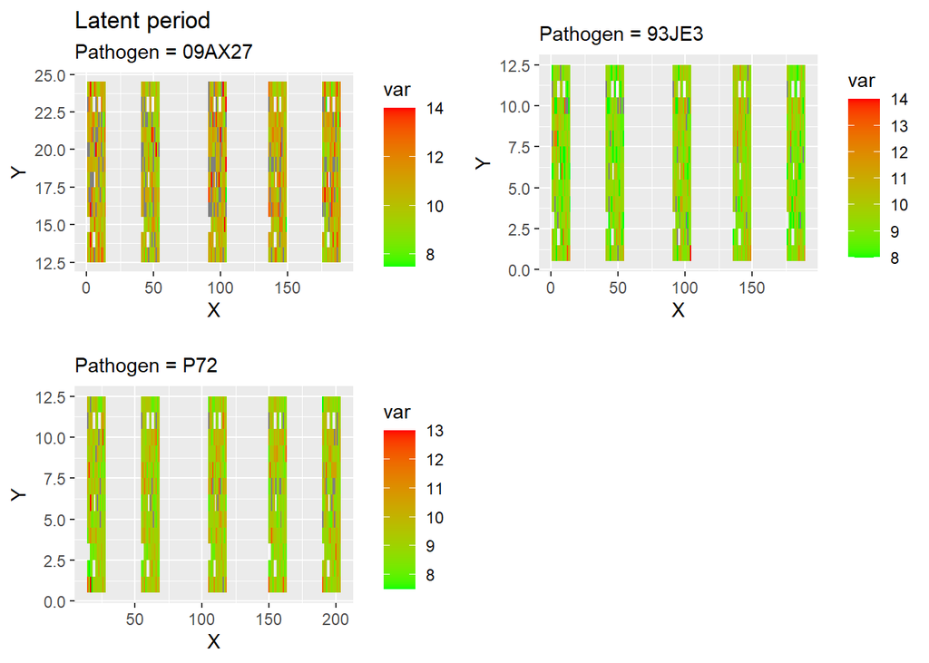

```r
fun.qplot = function(X_coord, Y_coord, var){
  qplot(X_coord, Y_coord, fill = var, geom = "tile",
        xlab = "X", ylab = "Y") +
    scale_fill_gradient(low = "green", high = "red")
}

# Pathogen = 09AX27
LP_09 = fun.qplot(X_coord = s09AX27_clean$X,
                  Y_coord = s09AX27_clean$Y,
                  var = s09AX27_clean$Laten_24.02.15_gp)

LP_09_title = LP_09 + labs(title = "Latent period",
                           subtitle = "Pathogen = 09AX27")

# Pathogen = 93JE3
LP_93 = fun.qplot(X_coord = s93JE3_clean$X,
                  Y_coord = s93JE3_clean$Y,
                  var = s93JE3_clean$Laten_24.02.15_gp)

LP_93_title = LP_93 + labs(title = element_blank(),
                           subtitle = "Pathogen = 93JE3")

# Pathogen = P72
LP_72 = fun.qplot(X_coord = sP72_clean$X,
                  Y_coord = sP72_clean$Y,
                  var = sP72_clean$Laten_24.02.15_gp)

LP_72_title = LP_72 + labs(title = element_blank(),
                           subtitle = "Pathogen = P72")

# Combining all the plots
LP_variation = ggpubr::ggarrange(LP_09_title, LP_93_title, LP_72_title)

LP_variation
```

From these plots, I can see that poplar individuals tended to start showing symptoms as early as day 8 (incubation period = 14 days). This is true for the poplars infected by pathogen 93JE3 and P72. The poplars that were infected by 09AX27 showed more variable response.

## For variable uredinia number

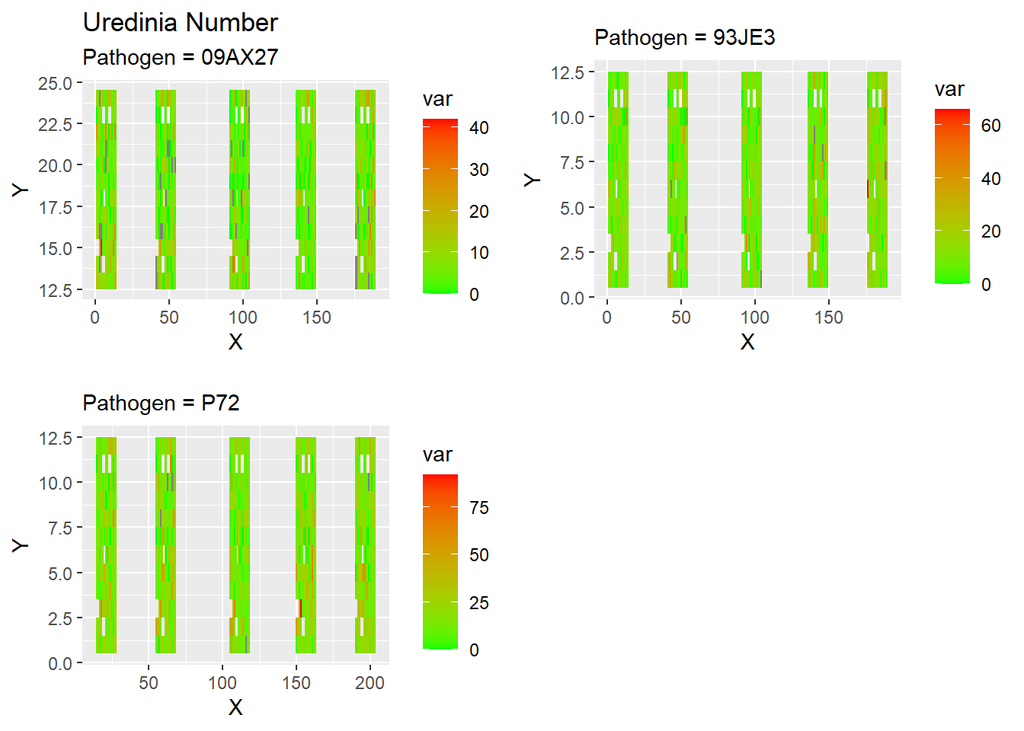

```r
# Pathogen 09AX27
UN_09 = fun.qplot(X_coord = s09AX27_clean$X,
                  Y_coord = s09AX27_clean$Y,
                  var = s09AX27_clean$total_NbSS)

UN_09_title = UN_09 + labs(title = "Uredinia Number",
                           subtitle = "Pathogen = 09AX27")

# Pathogen 93JE3
UN_93 = fun.qplot(X_coord = s93JE3_clean$X,
                  Y_coord = s93JE3_clean$Y,
                  var = s93JE3_clean$total_NbSS)

UN_93_title = UN_93 + labs(title = element_blank(),
                           subtitle = "Pathogen = 93JE3")

# Pathogen = P72
UN_72 = fun.qplot(X_coord = sP72_clean$X,
                  Y_coord = sP72_clean$Y,
                  var = sP72_clean$total_NbSS)

UN_72_title = UN_72 + labs(title = element_blank(),
                           subtitle = "Pathogen = P72")

UN_variation = ggpubr::ggarrange(UN_09_title, UN_93_title, UN_72_title)

UN_variation
```

It is not very easy to compare the variation in uredinia number across pathogens. There is a high range of uredinia number for each pathogen. However, I can see that individuals infected by pathogen 09AX27 showed smaller amount of uredinia than the other individuals infected by 93JE3 and P72. Some individuals infected by P72 showed the largest amount of uredinia, but most of them tended to have uredinia number far below the largest amount.

## For variable uredinia size

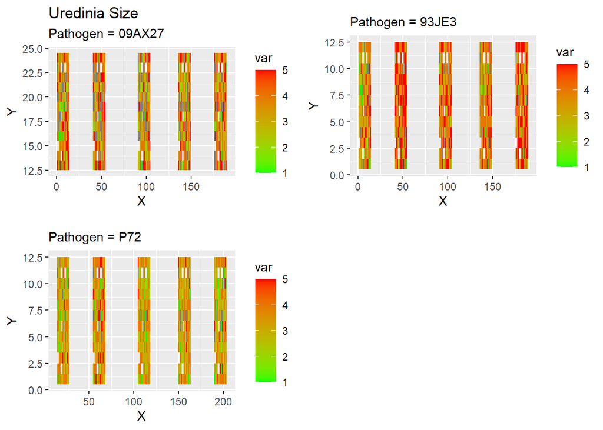

```r
# Pathogen 09AX27
US_09 = fun.qplot(X_coord = s09AX27_clean$X,
                  Y_coord = s09AX27_clean$Y,
                  var = s09AX27_clean$Taill_05.08.20_gp)

US_09_title = US_09 + labs(title = "Uredinia Size",
                           subtitle = "Pathogen = 09AX27")

# Pathogen 93JE3
US_93 = fun.qplot(X_coord = s93JE3_clean$X,
                  Y_coord = s93JE3_clean$Y,
                  var = s93JE3_clean$Taill_05.08.20_gp)

US_93_title = US_93 + labs(title = element_blank(),
                           subtitle = "Pathogen = 93JE3")

# Pathogen P72
US_72 = fun.qplot(X_coord = sP72_clean$X,
                  Y_coord = sP72_clean$Y,
                  var = sP72_clean$Taill_05.08.20_gp)

US_72_title = US_72 + labs(title = element_blank(),
                           subtitle = "Pathogen = P72")

US_variation = ggpubr::ggarrange(US_09_title, US_93_title, US_72_title)

US_variation
```

The uredinia size was scored in 1 - 5 scales (1 being the smallest, 5 being the largest). I can see that individuals infected by pathogen 93JE3 were suffering from spores with big sizes. There seem to be more poplars with big sizes when they were infected by 93JE3 than when they were infected by the other two. It is indicated by more uniformity of the red color in the graph for pathogen 93JE3 than in the graphs for the other two pathogens.

Moreover, I can see a lighter color populating the graph for pathogen P72. It indicates that the poplars infected P72 were suffering from spores with smaller sizes than the poplars infected by the other two.

# The average response of the individuals toward the pathogens.

As I mentioned above, I had an experimental design of poplar individuals spread across 5 blocks. The blocks were served as repetition. For each of the resistance component, I wanted to average the values across 5 blocks (or repetitions) so that I would get one value for one individual. Then I would plot the resistance components of the individuals.

## Resistance component 1: Latent period

```r
# Some preparation

# Creating the function for mean
mean.all = function(x, Genotype){
  data.frame(aggregate(x, by = Genotype, mean, na.rm = TRUE))
}

# Creating the function for standard deviation
sd.all = function(x, Genotype){
  data.frame(aggregate(x, by = Genotype, sd, na.rm = TRUE))
}

# Creating list for loop
strain_list = list(s09AX27_clean, s93JE3_clean, sP72_clean)

mean_laten = list()

sd_laten = list()

for (i in 1:length(strain_list)) {

  mean_laten[[i]] = mean.all(strain_list[[i]]$Laten_24.02.15_gp,
                              list(strain_list[[i]]$Genotype))

  dat_mean_laten = as.data.frame(mean_laten)

  sd_laten[[i]] = sd.all(strain_list[[i]]$Laten_24.02.15_gp,
                          list(strain_list[[i]]$Genotype))

  dat_sd_laten = as.data.frame(sd_laten)
}

names(dat_mean_laten) = c("s09AX27", "Mean_09AX27",
                           "s93JE3", "Mean_93JE3",
                           "sP72", "Mean_P72")

dat_mean_laten[dat_mean_laten == "NaN"] = NA

names(dat_sd_laten) = c("s09AX27", "Sd_09AX27",
                         "s93JE3", "Sd_93JE3",
                         "sP72", "Sd_P72")

# Extract the individuals for each pathogen
s09AX27_means = data.frame(
  Genotype = as.character(levels(as.factor(s09AX27_clean$Genotype)))
  )

s93JE3_means = data.frame(
  Genotype = as.character(levels(as.factor(s93JE3_clean$Genotype)))
  )

sP72_means = data.frame(
  Genotype = as.character(levels(as.factor(sP72_clean$Genotype)))
  )

# Join them (per pathogen) with sd and mean
s09AX27_means$LP_mean = dat_mean_laten$Mean_09AX27
s09AX27_means$LP_sd = dat_sd_laten$Sd_09AX27

s93JE3_means$LP_mean = dat_mean_laten$Mean_93JE3
s93JE3_means$LP_sd = dat_sd_laten$Sd_93JE3

sP72_means$LP_mean = dat_mean_laten$Mean_P72
sP72_means$LP_sd = dat_sd_laten$Sd_P72
```

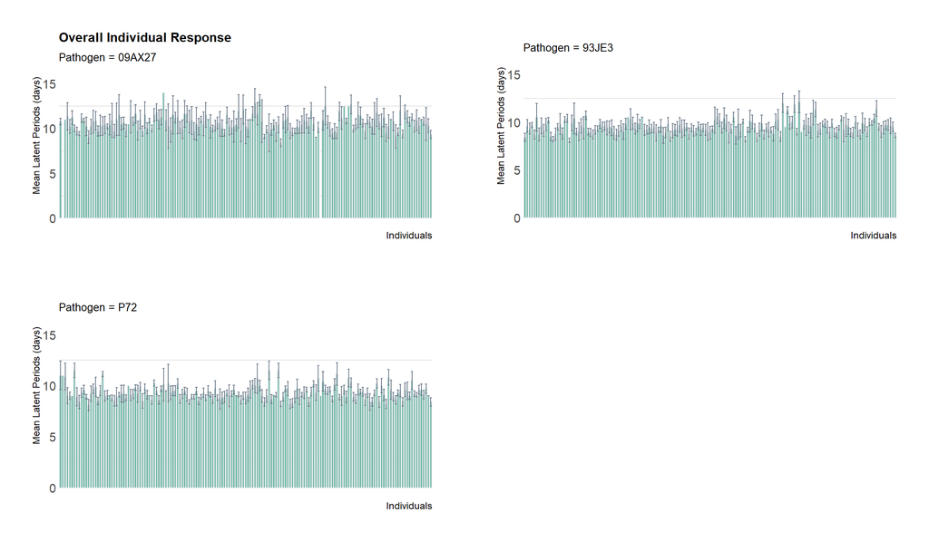

```r
# Graphical inspection for pathogen 09AX27
LP_mean_09 =
  ggplot(data = s09AX27_means) +
  geom_bar(aes(x = Genotype, y = LP_mean),
           stat = "identity",
           fill = "#69b3a2",
           color = "#e9ecef",
           alpha = 0.9) +
  geom_errorbar(aes(x = Genotype, ymin = LP_mean - LP_sd,
                    ymax = LP_mean + LP_sd), color = "#6E7B8B", size = 0.5) +
  labs(x = "Individuals", y = "Mean Latent Periods (days)",
       title = "Overall Individual Response", subtitle = "Pathogen = 09AX27") +
  ylim(0,15) +
  hrbrthemes::theme_ipsum() +
  theme(axis.text.x = element_blank(),
        plot.title = element_text(size = 12),
        plot.subtitle = element_text(size = 10),
        panel.grid.major = element_blank())

# Graphical inspection for pathogen 93JE3
LP_mean_93 =
  ggplot(data = s93JE3_means) +
  geom_bar(aes(x = Genotype, y = LP_mean),
           stat = "identity",
           fill = "#69b3a2",
           color = "#e9ecef",
           alpha = 0.9) +
  geom_errorbar(aes(x = Genotype, ymin = LP_mean - LP_sd,
                    ymax = LP_mean + LP_sd), color = "#6E7B8B", size = 0.5) +
  labs(x = "Individuals", y = "Mean Latent Periods (days)",
       title = element_blank(), subtitle = "Pathogen = 93JE3") +
  ylim(0,15) +
  hrbrthemes::theme_ipsum() +
  theme(axis.text.x = element_blank(),
        plot.subtitle = element_text(size = 10),
        panel.grid.major = element_blank())

# Graphical inspection for pathogen P72
LP_mean_72 =
ggplot(data = sP72_means) +
  geom_bar(aes(x = Genotype, y = LP_mean),
           stat = "identity",
           fill = "#69b3a2",
           color = "#e9ecef",
           alpha = 0.9) +
  geom_errorbar(aes(x = Genotype, ymin = LP_mean - LP_sd,
                    ymax = LP_mean + LP_sd), color = "#6E7B8B", size = 0.5) +
  labs(x = "Individuals", y = "Mean Latent Periods (days)",
       subtitle = "Pathogen = P72") +
  ylim(0,15) +
  hrbrthemes::theme_ipsum() +
  theme(axis.text.x = element_blank(),
        plot.subtitle = element_text(size = 10),
        panel.grid.major = element_blank())

LP_mean_graph = ggpubr::ggarrange(LP_mean_09, LP_mean_93, LP_mean_72)

LP_mean_graph
```

In conjunction to the previous step, this is a clearer representative on poplar’s behavior across pathogen types.

**Latent period.** After averaging the latent period for each individual, I got this distribution. Individuals are placed on the x-axis and the mean latent period on the y-axis. Across pathogen types, individuals tended to start showing the first symptom between day 9 to 11 after inoculation (i.e. exposure to pathogen).

## Resistance component 2: Uredinia number

```r
# Preparing the mean and standard deviation

# List for loop = strain_list
# Function: mean.all and sd.all

mean_UN = list()

sd_UN = list()

for (i in 1:length(strain_list)) {
  mean_UN[[i]] = mean.all(strain_list[[i]]$total_NbSS,
                          list(strain_list[[i]]$Genotype))

  dat_mean_UN = as.data.frame(mean_UN)

  sd_UN[[i]] = sd.all(strain_list[[i]]$total_NbSS,
                      list(strain_list[[i]]$Genotype))

  dat_sd_UN = as.data.frame(sd_UN)
}

names(dat_mean_UN) = c("s09AX27", "UN_Mean_09AX27",
                        "s93JE3", "UN_Mean_93JE3",
                        "sP72", "UN_Mean_P72")

names(dat_sd_UN) = c("s09AX27", "Sd_09AX27",
                      "s93JE3", "Sd_93JE3",
                      "sP72", "Sd_P72")

# Join them (per strain) with sd and mean
s09AX27_means$UN_mean = dat_mean_UN$UN_Mean_09AX27
s09AX27_means$UN_sd = dat_sd_UN$Sd_09AX27

s93JE3_means$UN_mean = dat_mean_UN$UN_Mean_93JE3
s93JE3_means$UN_sd = dat_sd_UN$Sd_93JE3

sP72_means$UN_mean = dat_mean_UN$UN_Mean_P72
sP72_means$UN_sd = dat_sd_UN$Sd_P72
```

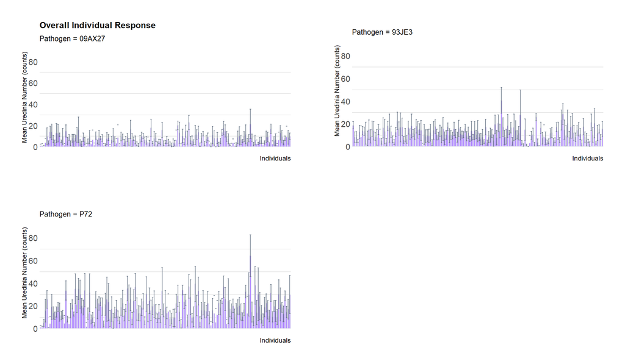

```r
# Graphical inspection (UN) for pathogen 09AX27
UN_mean_09 =
  ggplot(data = s09AX27_means) +
  geom_bar(aes(x = Genotype, y = UN_mean),
           stat = "identity",
           fill = "#AB82FF",
           color = "#e9ecef",
           alpha = 0.9) +
  geom_errorbar(aes(x = Genotype, ymin = UN_mean - UN_sd,
                    ymax = UN_mean + UN_sd), color = "#6E7B8B", size = 0.5) +
  labs(x = "Individuals", y = "Mean Uredinia Number (counts)",
       title = "Overall Individual Response", subtitle = "Pathogen = 09AX27") +
  ylim(0,85) +
  hrbrthemes::theme_ipsum() +
  theme(axis.text.x = element_blank(),
        plot.title = element_text(size = 12),
        plot.subtitle = element_text(size = 10),
        panel.grid.major = element_blank())

# Graphical inspection (UN) for pathogen 93JE3
UN_mean_93 =
  ggplot(data = s93JE3_means) +
  geom_bar(aes(x = Genotype, y = UN_mean),
           stat = "identity",
           fill = "#AB82FF",
           color = "#e9ecef",
           alpha = 0.9) +
  geom_errorbar(aes(x = Genotype, ymin = UN_mean - UN_sd,
                    ymax = UN_mean + UN_sd), color = "#6E7B8B", size = 0.5) +
  labs(x = "Individuals", y = "Mean Uredinia Number (counts)",
       title = element_blank(), subtitle = "Pathogen = 93JE3") +
  ylim(0,85) +
  hrbrthemes::theme_ipsum() +
  theme(axis.text.x = element_blank(),
        plot.title = element_text(size = 12),
        plot.subtitle = element_text(size = 10),
        panel.grid.major = element_blank())

# Graphical inspection (UN) for pathogen P72
UN_mean_72 =
  ggplot(data = sP72_means) +
  geom_bar(aes(x = Genotype, y = UN_mean),
           stat = "identity",
           fill = "#AB82FF",
           color = "#e9ecef",
           alpha = 0.9) +
  geom_errorbar(aes(x = Genotype, ymin = UN_mean - UN_sd,
                    ymax = UN_mean + UN_sd), color = "#6E7B8B", size = 0.5) +
  labs(x = "Individuals", y = "Mean Uredinia Number (counts)",
       title = element_blank(), subtitle = "Pathogen = P72") +
  ylim(0,85) +
  hrbrthemes::theme_ipsum() +
  theme(axis.text.x = element_blank(),
        plot.title = element_text(size = 12),
        plot.subtitle = element_text(size = 10),
        panel.grid.major = element_blank())

UN_mean_graph = ggpubr::ggarrange(UN_mean_09, UN_mean_93, UN_mean_72)

UN_mean_graph
```

**Uredinia number.** Once the spore started populating poplar’s leaves, individuals infected by P72 were suffering from the largest amount of spore.

## Resistance component 3: Uredinia size

```r
# Preparing the mean and standard deviation

# List for loop = strain_list
# Function: mean.all and sd.all

mean_US = list()

sd_US = list()

for (i in 1:length(strain_list)) {
  mean_US[[i]] = mean.all(strain_list[[i]]$Taill_05.08.20_gp,
                           list(strain_list[[i]]$Genotype))

  dat_mean_US = as.data.frame(mean_US)

  sd_US[[i]] = sd.all(strain_list[[i]]$Taill_05.08.20_gp,
                       list(strain_list[[i]]$Genotype))

  dat_sd_US = as.data.frame(sd_US)
}

names(dat_mean_US) = c("s09AX27", "US_Mean_09AX27",
                        "s93JE3", "US_Mean_93JE3",
                        "sP72", "US_Mean_P72")

names(dat_sd_US) = c("s09AX27", "Sd_09AX27",
                      "s93JE3", "Sd_93JE3",
                      "sP72", "Sd_P72")

# Join them (per pathogen) with sd and mean
s09AX27_means$US_mean = dat_mean_US$US_Mean_09AX27
s09AX27_means$US_sd = dat_sd_US$Sd_09AX27

s93JE3_means$US_mean = dat_mean_US$US_Mean_93JE3
s93JE3_means$US_sd = dat_sd_US$Sd_93JE3

sP72_means$US_mean = dat_mean_US$US_Mean_P72
sP72_means$US_sd = dat_sd_US$Sd_P72
```

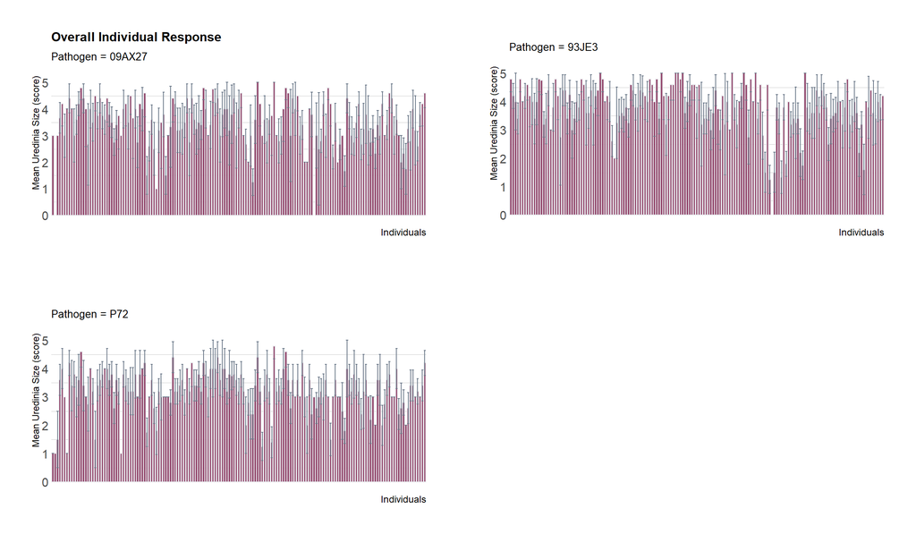

```r
# Graphical inspection (US) for pathogen 09AX27
US_mean_09 =
  ggplot(data = s09AX27_means) +
  geom_bar(aes(x = Genotype, y = US_mean),
           stat = "identity",
           fill = "#8B3A62",
           color = "#e9ecef",
           alpha = 0.9) +
  geom_errorbar(aes(x = Genotype, ymin = US_mean - US_sd,
                    ymax = US_mean + US_sd), color = "#6E7B8B", size = 0.5) +
  labs(x = "Individuals", y = "Mean Uredinia Size (score)",
       title = "Overall Individual Response", subtitle = "Pathogen = 09AX27") +
  ylim(0,5) +
  hrbrthemes::theme_ipsum() +
  theme(axis.text.x = element_blank(),
        plot.title = element_text(size = 12),
        plot.subtitle = element_text(size = 10),
        panel.grid.major = element_blank())

# Graphical inspection (US) for pathogen 93JE3
US_mean_93 =
  ggplot(data = s93JE3_means) +
  geom_bar(aes(x = Genotype, y = US_mean),
           stat = "identity",
           fill = "#8B3A62",
           color = "#e9ecef",
           alpha = 0.9) +
  geom_errorbar(aes(x = Genotype, ymin = US_mean - US_sd,
                    ymax = US_mean + US_sd), color = "#6E7B8B", size = 0.5) +
  labs(x = "Individuals", y = "Mean Uredinia Size (score)",
       title = element_blank(), subtitle = "Pathogen = 93JE3") +
  ylim(0,5) +
  hrbrthemes::theme_ipsum() +
  theme(axis.text.x = element_blank(),
        plot.title = element_text(size = 12),
        plot.subtitle = element_text(size = 10),
        panel.grid.major = element_blank())

# Graphical inspection (US) for pathogen P72
US_mean_72 =
  ggplot(data = sP72_means) +
  geom_bar(aes(x = Genotype, y = US_mean),
           stat = "identity",
           fill = "#8B3A62",
           color = "#e9ecef",
           alpha = 0.9) +
  geom_errorbar(aes(x = Genotype, ymin = US_mean - US_sd,
                    ymax = US_mean + US_sd), color = "#6E7B8B", size = 0.5) +
  labs(x = "Individuals", y = "Mean Uredinia Size (score)",
       title = element_blank(), subtitle = "Pathogen = P72") +
  ylim(0,5) +
  hrbrthemes::theme_ipsum() +
  theme(axis.text.x = element_blank(),
        plot.title = element_text(size = 12),
        plot.subtitle = element_text(size = 10),
        panel.grid.major = element_blank())

US_mean_graph = ggpubr::ggarrange(US_mean_09, US_mean_93, US_mean_72)

US_mean_graph
```

Approaching the end of incubation period, individuals infected by 93JE were suffering from spore with larger sizes than the individuals infected by 09AX27 and P72.